# IODS course project

## Linear discriminant analysis and visualization

Next, I will fit the linear discriminant analysis on the train set using the categorical crime rate as the target variable and all the other variables in the dataset as predictor variables.

```r
# fit analysis


lda.fit <- lda(crime ~ ., data = train)
lda.fit
```

```
## Call:
## lda(crime ~ ., data = train)
##
## Prior probabilities of groups:
##       low   med_low  med_high      high
## 0.2549505 0.2425743 0.2500000 0.2524752
##
## Group means:
##                  zn      indus        chas        nox         rm        age
## low       0.8456976 -0.8999766 -0.11943197 -0.8521533  0.4144789 -0.8570644
## med_low  -0.0820950 -0.3122263 -0.11163110 -0.5657105 -0.1360681 -0.2452487
## med_high -0.4006369  0.2593397  0.19544522  0.4216463  0.1273869  0.5001468
## high     -0.4872402  1.0171096 -0.04073494  1.0561428 -0.4144408  0.8064827
##                 dis        rad        tax    ptratio      black       lstat
## low       0.8578062 -0.6841618 -0.7355371 -0.4279126  0.3767090 -0.75564017
## med_low   0.3416992 -0.5541258 -0.4613676 -0.1038924  0.3068444 -0.08870830
## med_high -0.3857597 -0.4065006 -0.2765177 -0.2780986  0.0753963 -0.01201999
## high     -0.8547857  1.6382099  1.5141140  0.7808718 -0.7447632  0.88009043
##                 medv
## low       0.49458471
## med_low  -0.02786483
## med_high  0.15619053
## high     -0.66617969
##
## Coefficients of linear discriminants:
##                 LD1         LD2          LD3
## zn       0.08141520  0.59861041 -0.920591285
## indus    0.04286873 -0.29852049  0.175513246
## chas    -0.09801626 -0.04778317 -0.021417736
## nox      0.39417988 -0.66078454 -1.378505216
## rm      -0.07271376 -0.14039962 -0.151042907
## age      0.33131783 -0.47112760 -0.008309867
## dis      0.02160991 -0.25373973  0.061970702
## rad      3.15658527  1.01716846 -0.253642062
## tax      0.06136537 -0.11727224  0.728040764
## ptratio  0.11138113  0.01267153 -0.323562608
## black   -0.11448106  0.04026634  0.139408850
## lstat    0.16321013 -0.14358294  0.471572871
## medv     0.17277781 -0.35483776 -0.145029705
##
## Proportion of trace:
##    LD1    LD2    LD3
## 0.9500 0.0382 0.0118
```

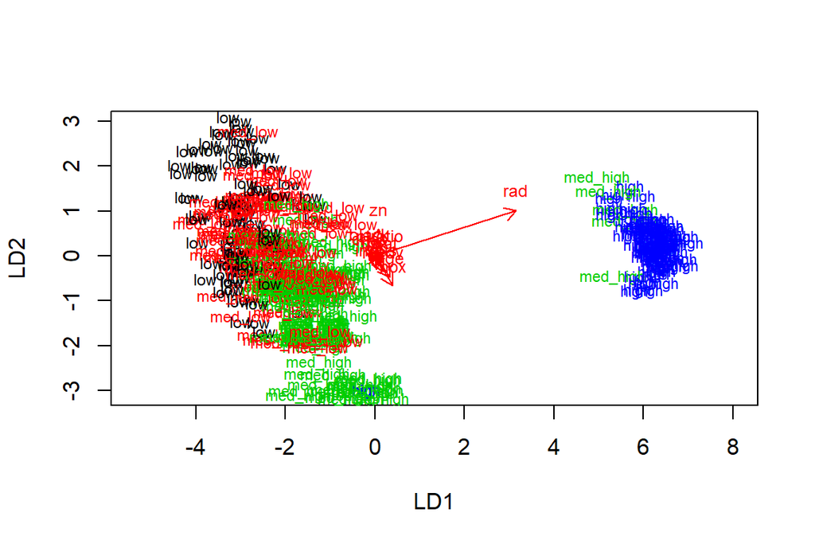

```r
#draw model
lda.arrows <- function(x, myscale = 1, arrow_heads = 0.1, color = "red", tex = 0.75, choices = c(1,2)){
  heads <- coef(x)
  arrows(x0 = 0, y0 = 0,
         x1 = myscale * heads[,choices[1]],
         y1 = myscale * heads[,choices[2]], col=color, length = arrow_heads)
  text(myscale * heads[,choices], labels = row.names(heads),
       cex = tex, col=color, pos=3)
}

classes <- as.numeric(train$crime)

plot(lda.fit, dimen = 2, col= classes, pch = classes)
lda.arrows(lda.fit, myscale = 1)
```

In this two-dimensional figure, high is relatively distinguishable from the rest - even though that there are a few med_highs in the cluster.The rest of the classes are quite crammed together.

## Predicting classes with the LDA model on the test data

Now I will predict the classes with the LDA model on the test data and cross tabulate the results with the crime categories from the test set.

```r
# save the crime categories from the test set
correct_classes <- test$crime

# remove the categorical crime variable from the test dataset
test <- dplyr::select(test, -crime)

# predict the classes with the LDA model on the test data

lda.pred <- predict(lda.fit, newdata = test)
table(correct = correct_classes, predicted = lda.pred$class)
```

```
##           predicted
## correct    low med_low med_high high
##   low       19       5        0    0
##   med_low    7      17        4    0
##   med_high   3       8       13    1
##   high       0       0        0   25
```

## K-means clustering

For the K-means clustering, I will reload the Boston dataset and standardize the dataset. Below you can find also the calculated euclidean and manhattan distances between the observations.

```r
library (MASS)
data ("Boston")
boston_scaled1 <- scale(Boston)
boston_scaled1 <- as.data.frame(boston_scaled1)

dist_eu <- dist(boston_scaled1)
dist_man <- dist(boston_scaled1, method = 'manhattan')
summary(dist_eu)
```

```
##    Min. 1st Qu.  Median    Mean 3rd Qu.    Max.
##  0.1343  3.4625  4.8241  4.9111  6.1863 14.3970
```

```r
summary(dist_man)
```

```
##    Min. 1st Qu.  Median    Mean 3rd Qu.    Max.
##  0.2662  8.4832 12.6090 13.5488 17.7568 48.8618
```

Nest, I will run k-means algorithm on the datase and Visualize the clusters.

[figure not shown]

```r
# Run k-means on the dataset.
km <- kmeans(boston_scaled1, centers=4)

# visualize
pairs(boston_scaled1, col = km$cluster)
```

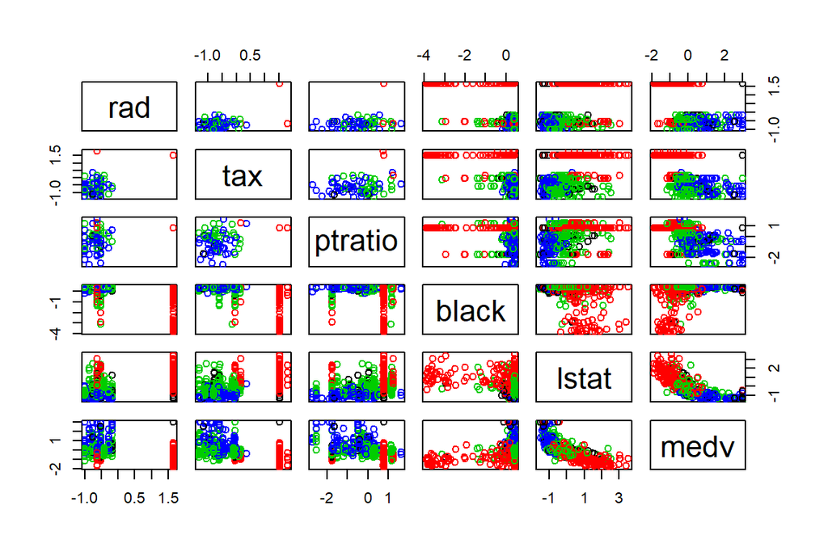

```r
# cannot see a thing, zooming into last five variables
pairs(boston_scaled1 [9:14], col = km$cluster)
```